# pres_Kalman_Nonlinear slides

## Extended Kalman Filter

### MEC 560: Advanced Control Systems

#### Vivek Yadav, PhD

### Overview

- Observability of nonlinear systems
- EKF: Extended Kalman Filter for nonlinear system
- EKF vs UKF

### Observability matrix

Observability for nonlinear system \( \dot{X} = f(X) + g(X)u \) with measurement \( y = h(x) \) is given by

is given by,

$$ O(f,h) = [ L^0_fh^T~ L^1_fh^T~ L^2_fh^T~ \dots ~ L^{n-1}_fh^T] $$

If the observability matrix above has a full rank, then the states of the system can be estimated. Note, observability matrix may lose rank in some state-space and could potentially become unobservable.

### Extended Kalman Filter (EKF)

Consider the nonlinear system given by,

$$ X_{k} = f(X_{k-1}) + w_{k-1} $$

with measurement

$$ Z_{k} = h(X_{k}) + v_{k} $$

where \( w_k\) and \( v_k \) represent process and measurement noise with means 0 and covarances given by \(Q_k\) and \(R_k\). We further assume that state covariance is given by a matrix \( P \). Detailed derivation of extended kalman filter can be found [here](https://homes.cs.washington.edu/~todorov/courses/cseP590/readings/tutorialEKF.pdf). The EKF is implemeted in the following steps.

#### Model and observation

Given the model

$$ X_{k} = f(X_{k-1}) + Fw_{k-1} $$

with measurement

$$ Z_{k} = h(X_{k}) + v_{k} $$

#### Initialization

$$ \hat{X}_0 = \mu_0$$$$ P_0 = P_0$$

#### Forecasting step

$$ \hat{X}_{k}^- = f(\hat{X}_{k-1}^+) $$$$ P_{k}^- = \frac{\partial f}{\partial X} P_{k-1}^+ \frac{\partial f}{\partial X}^T + FQ_{k-1}F' $$

where the partial derivatives are evaluate at \( X_{k-1}^+ \).

#### Correction step

$$ K_k = P_{k}^- \frac{\partial h}{\partial X}^T \left( \frac{\partial h}{\partial X} P_{k}^-\frac{\partial h}{\partial X}^T + R_k \right)^{-1}$$$$ P_k^+ = \left( I - K_k \frac{\partial h}{\partial X} \right)P_{k}^- $$

The partial derivatives are evaluated at \( X_{k}^- \).

$$ X_k^+ = X_k^- + K_k(Z_k - h(X_k^-)) $$

### Unicycle example:

Consider the dynamics of a unicycle car moving along a straight line at angle of 45-degrees.

$$ \dot{x} = V cos(\theta) $$

$$ \dot{y} = V sin(\theta) $$

$$ \dot{\theta} = \omega $$

#### Discretizing,

$$ x_{k+1} = x_k + \delta t(V_k+w_v) cos(\theta) $$

$$ y_{k+1} = y_k +\delta t(V_k+w_v) sin(\theta) $$

$$ \theta_{k+1} = \theta_k + \delta t(\omega_k+w_\omega) $$

#### Separating noise and state terms gives,

$$ \left[ \begin{array}{c} x_{k+1} \\ y_{k+1} \\ \theta_{k+1} \end{array} \right] = \left[ \begin{array}{c} x_k + \delta t V_k cos(\theta) \\ y_k +\delta tV_k sin(\theta) \\ \theta_k + \delta t \omega_k \end{array} \right] + \left[\begin{array}{cc} \delta t cos(\theta) & 0 \\ \delta t sin(\theta) & 0 \\ 0 & \delta t \end{array} \right] \left[\begin{array}{c} w_v \\ w_\omega \end{array} \right] $$

```python
clc
close all
clear all


dt = 0.001;
v = .5;
head_ang = pi/4;


C = [1 0 0;
    0 1 0];
R = diag([.001 .001]);

Q = diag([.1 .01]);
P_pl = eye(3);

X_hat_0 = [0;0;0];
X_0 = [.1;.1;head_ang];
X_hat_0 = X_0/2;


X(:,1)= X_0;
Y(:,1) = C*X(:,1);
t(1) = 0;
X_hat(:,1)= X_hat_0;
```

```python
for i = 1:4000
    u = [.5;0];

    t(i+1) = t(i)+dt;
    % True process
    X(:,i+1)= X(:,i) + dt*[u(1)*cos(X(3,i));
        u(1)*sin(X(3,i));
        u(2);];
    Y(:,i+1) = C*X(:,i+1) + sqrt(R)*randn(size(C,1),1);  %*randn(2,1);
    % Observer model

    dFdx = [0 0 -v*sin(X_hat(3,i)); 0 0 v*cos(X_hat(3,i)); 0 0 0 ];
    dFdx_d = eye(3) + dt*dFdx;

    F = [dt*cos(X_hat(3,i)) 0;
    dt*sin(X_hat(3,i)) 0;
    0 dt];

    P_mi = dFdx_d*P_pl*dFdx_d' + F*Q*F';

    X_hat(:,i+1) = X_hat(:,i) + dt*[u(1)*cos(X_hat(3,i));
            u(1)*sin(X_hat(3,i));
          u(2);];
    Y_hat(:,i+1) = C*X_hat(:,i+1);
    % Update based on measurement
    e_Y  = Y(:,i+1) - Y_hat(:,i+1);
    S = C*P_mi*C'+R;
    K = P_mi*C'*inv(S);
    P_pl = (eye(3) - K*C)*P_mi;
    X_hat(:,i+1)=X_hat(:,i+1) + K*e_Y;
end
X_hat(3,1) = X_hat(3,end);
P_pl = P_mi;
```

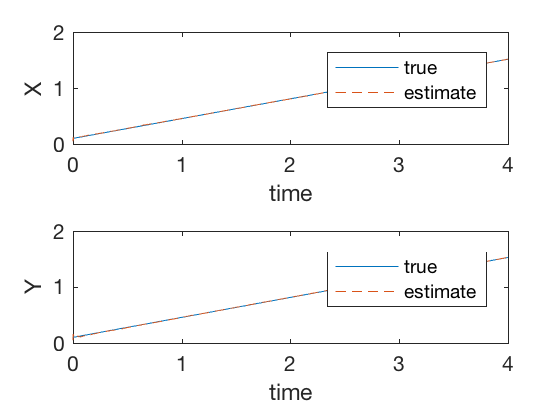

```python
figure;
subplot(2,1,1)
plot(t,X(1,:),t,X_hat(1,:),'--')
legend('true','estimate')
%axis([0 2.5 0 40])
xlabel('time')
ylabel('X')
axis([0 4 0 2])
subplot(2,1,2)
plot(t,X(2,:),t,X_hat(2,:),'--')
legend('true','estimate')
xlabel('time')
ylabel('Y')
axis([0 4 0 2])
```

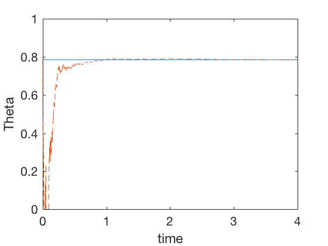

```python
figure;
plot(t,X(3,:),t,X_hat(3,:),'--')
axis([0 4 0 1])
xlabel('time')
ylabel('Theta')
%axis([0 2.5 0 2])
```

### Conclusion: Extended Kalman filter.

- Works well for most nonlinear systems
- Calculating apriori covariance requires linearization approximation, which may not be true.
- For highly nonlinear systems, can result in erroneous estiamtes

#### Unscented transform

- Unscented transforms are used to obtain a better estimate of covariance matrix
- Choose some sigma points, propagate state and compute new covariance directly

[figure not shown]